# Aula 05

Pacotes utilizados neste RMD.

```r
library("rmdformats")
library("readxl")
```

# Teste de hipóteses

## Elementos de um teste de hipóteses estatístico

1. Hipóteses $H_0$ (hipótese nula) e $H_1$ (hipótese alternativa, que é o foco da pesquisa);
2. Nível de significância $\alpha$;
3. Estatística do teste;
4. Valor do $p$;

### Exemplo: tratamento de cães

### Sobre as hipóteses.

Hipótese Unilateral à direita: $H_1$ maior que um certo valor.

Hipótese Unilateral à esquerda: $H_1$ menor que um certo valor.

Hipótese Bilateral: $H_1$ diferente de um certo valor.

### Nível de significância.

Probabilidade de rejeitar $H_0$ quando ela é verdadeira (conhecida como a probabilidade do erro tipo I).

$P(Erro I) = \alpha = P(RejeitarH_0|H_0 verdadeira)$

$P(Erro II) = \beta = P(NaoRejeitarH_0|H_0 falsa)$

Costuma-se usar $alpha = 0.05$.

### Valor de p

Probabilidade à direita, a rejeição vai depender se a hipótese é unilateral ou bilateral tb (tomar cuidado).

## Teste de hipóteses para uma proporção populacional

Usamos a estatística da Qui-quadrado (rever o exemplo)

Quanto maior a diferença entre observado e esperado, maior a estatística e maior a chance de que aquilo não segue a determinada proporção esperada.

```r
oi <- c(33,12) # Valores observados
ei <- c(45*0.5,45*0.5) # Valores esperados

(estat <- sum((oi-ei)^2/ei))
```

```
## [1] 9.8
```

```r
1-pchisq(estat,df=1)
```

```
## [1] 0.001745119
```

```r
prop.test(33,45,p=0.5,correct=F,alternative = "g")
```

```
##
##  1-sample proportions test without continuity correction
##
## data:  33 out of 45, null probability 0.5
## X-squared = 9.8, df = 1, p-value = 0.0008726
## alternative hypothesis: true p is greater than 0.5
## 95 percent confidence interval:
##  0.61396 1.00000
## sample estimates:
##         p
## 0.7333333
```

Logo, não há uma proporção de $0.5$. A proporção real de melhora é de aproximadamente $73.33\%$.

(Obs: se o valor esperado for menor que 5, não é possível aplicar o teste qui-quadrado).

## Testes para média populacional

Ideia parecida com a do intervalo de confiança visto na aula anterior.

Estatística do teste: t-student

Exemplo, supondo a hipótese nula com uma média maior ou igual à 25.

```r
dadosIC <- read_excel("dadosIC.xlsx", sheet = "Comprimento")
head(dadosIC)
```

```
## # A tibble: 6 × 1
##   comprimento
##         <dbl>
## 1        23.5
## 2        23.4
## 3        23.7
## 4        25.5
## 5        24.7
## 6        25
```

```r
attach(dadosIC)
```

Podemos começar com uma análise descritiva e exploratória.

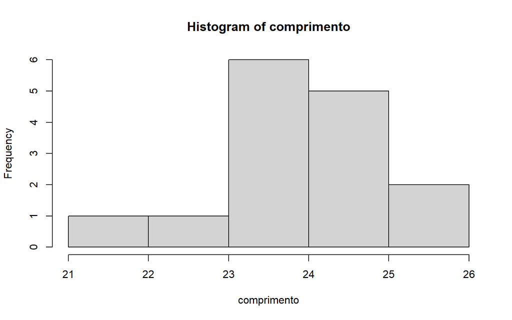

```r
hist(comprimento)
```

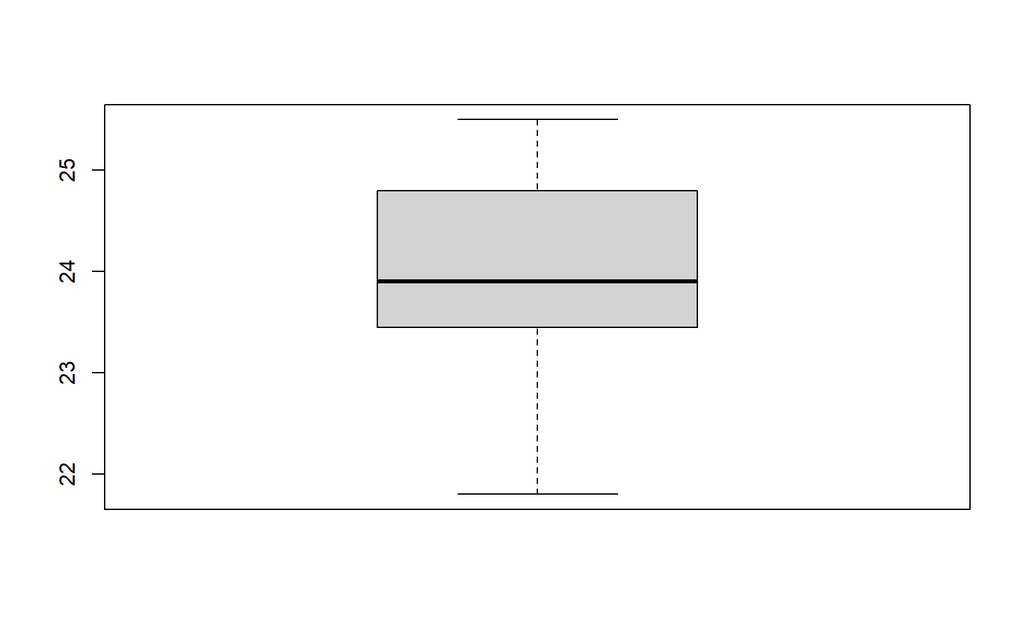

```r
boxplot(comprimento)
```

```r
n <- length(comprimento)
media <- mean(comprimento)
dp <- sd(comprimento)

estat <- (media-25)*sqrt(n)/dp

pt(estat,df=n-1)
```

```
## [1] 0.0006087465
```

```r
t.test(comprimento, mu=25, alternative = "l")
```

```
##
##  One Sample t-test
##
## data:  comprimento
## t = -4.0397, df = 14, p-value = 0.0006087
## alternative hypothesis: true mean is less than 25
## 95 percent confidence interval:
##      -Inf 24.40592
## sample estimates:
## mean of x
##  23.94667
```

Logo, a hipótese nula é rejeitada, a verdadeira média é menor que 25.

Tudo isso que fizemos foi supondo uma distribuição normal, mas e se não pudermos?

## Teste Shapiro-Wilk

Objetivo é verificar se a distribuição normal. $H_0$ é sempre a distribuição-alvo, que no caso, é a distribuição normal.

$H_1$: distribuição da amostra não é normal.

```r
shapiro.test(comprimento)
```

```
##
##  Shapiro-Wilk normality test
##
## data:  comprimento
## W = 0.96915, p-value = 0.8453
```

## Teste de Wilcoxon

Caso não seja normal